# PFD_order_products_Yosri_Saadi_Wahbi_Haj_kacem

```python
! pip install vaderSentiment
import pandas as pd
from sklearn.feature_extraction.text import TfidfVectorizer
from sklearn.linear_model import LogisticRegression
from sklearn.model_selection import train_test_split
import gensim
from vaderSentiment.vaderSentiment import SentimentIntensityAnalyzer
from gensim.utils import simple_preprocess
from gensim.models import Doc2Vec
from gensim.models.doc2vec import TaggedDocument
import pandas as pd
import re
import nltk #pour télécharger les ressources nécessaires de la bibliothèque NLTK, notamment les tokenizer (punkt) et les stopwords (stopwords).
nltk.download('punkt')
nltk.download('stopwords')
```

```
True
```

```python
# Load your dataset into a pandas dataframe
df = pd.read_csv('Produit.csv',delimiter=",")
```

```python
df.head()
```

|  | Unnamed: 0 | Clothing ID | Age | Title | Review Text | Rating | Recommended IND | Positive Feedback Count | Division Name | Department Name | Class Name |
| --- | --- | --- | --- | --- | --- | --- | --- | --- | --- | --- | --- |
| 0 | 0 | 767 | 33 | NaN | Absolutely wonderful - silky and sexy and comf... | 4 | 1 | 0 | Initmates | Intimate | Intimates |
| 1 | 1 | 1080 | 34 | NaN | Love this dress! it's sooo pretty. i happene... | 5 | 1 | 4 | General | Dresses | Dresses |
| 2 | 2 | 1077 | 60 | Some major design flaws | I had such high hopes for this dress and reall... | 3 | 0 | 0 | General | Dresses | Dresses |
| 3 | 3 | 1049 | 50 | My favorite buy! | I love, love, love this jumpsuit. it's fun, fl... | 5 | 1 | 0 | General Petite | Bottoms | Pants |
| 4 | 4 | 847 | 47 | Flattering shirt | This shirt is very flattering to all due to th... | 5 | 1 | 6 | General | Tops | Blouses |

```python
df.info()
```

```
<class 'pandas.core.frame.DataFrame'>
RangeIndex: 23486 entries, 0 to 23485
Data columns (total 11 columns):
 #   Column                   Non-Null Count  Dtype
---  ------                   --------------  -----
 0   Unnamed: 0               23486 non-null  int64
 1   Clothing ID              23486 non-null  int64
 2   Age                      23486 non-null  int64
 3   Title                    19676 non-null  object
 4   Review Text              22641 non-null  object
 5   Rating                   23486 non-null  int64
 6   Recommended IND          23486 non-null  int64
 7   Positive Feedback Count  23486 non-null  int64
 8   Division Name            23472 non-null  object
 9   Department Name          23472 non-null  object
 10  Class Name               23472 non-null  object
dtypes: int64(6), object(5)
memory usage: 2.0+ MB
```

```python
pip install nltk
```

```python
import nltk
import re
# Télécharger les ressources nécessaires
nltk.download('punkt')
nltk.download('stopwords')
```

```
True
```

```python
df['Review Text'] = df['Review Text'].astype(str)

# Fonction de nettoyage du texte
def clean_text(text):
    # Supprimer la ponctuation
    text = text.translate(str.maketrans('', '', string.punctuation))
    # Convertir en minuscules
    text = text.lower()
    return text

# Appliquer la fonction de nettoyage sur la colonne "Review Text"
df['cleaned_text'] = df['Review Text'].apply(clean_text)

# Tokenisation des phrases
tokenizer = nltk.tokenize.RegexpTokenizer(r'\w+')
df['tokens'] = df['cleaned_text'].apply(tokenizer.tokenize)

# Afficher les données après le nettoyage et la tokenisation
print(df[['Review Text', 'cleaned_text', 'tokens']])
```

```
                                             Review Text  \
0      Absolutely wonderful - silky and sexy and comf...
1      Love this dress!  it's sooo pretty.  i happene...
2      I had such high hopes for this dress and reall...
3      I love, love, love this jumpsuit. it's fun, fl...
4      This shirt is very flattering to all due to th...
...                                                  ...
23481  I was very happy to snag this dress at such a ...
23482  It reminds me of maternity clothes. soft, stre...
23483  This fit well, but the top was very see throug...
23484  I bought this dress for a wedding i have this ...
23485  This dress in a lovely platinum is feminine an...

                                            cleaned_text  \
0      absolutely wonderful  silky and sexy and comfo...
```

[output cut: 25 more lines]

```python
from gensim.models import Word2Vec

# Tokenisation des phrases
sentences = [str(review).split() for review in df['Review Text']]

# Entraîner le modèle Word2Vec
model = Word2Vec(sentences, vector_size=100, window=5, min_count=1, workers=4)
```

```python
similar_words = model.wv.most_similar('dress')
print(similar_words)
```

```
[('top', 0.8301398158073425), ('shirt', 0.8262062072753906), ('skirt', 0.8137812614440918), ('blouse', 0.810186505317688), ('sweater', 0.8083000183105469), ('coat', 0.7518038153648376), ('dress,', 0.7424531579017639), ('jumpsuit', 0.716362714767456), ('suit', 0.7111912369728088), ('dress.', 0.703535…
```

```python
word_vector = model.wv['dress']
print(word_vector)
```

[output not shown]

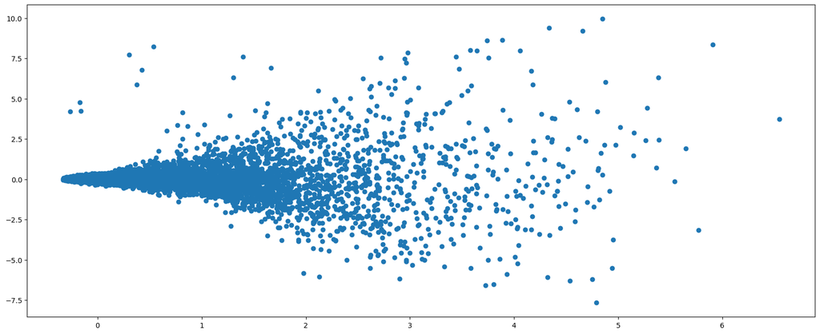

```python
# Visualize similar words in a 2D space
import matplotlib.pyplot as plt
from sklearn.decomposition import PCA

words = list(model.wv.key_to_index.keys())
vectors = [model.wv.get_vector(word) for word in words]

pca = PCA(n_components=2)
result = pca.fit_transform(vectors)

plt.figure(figsize=(20, 8))  # Adjust the figure size as needed
plt.scatter(result[:, 0], result[:, 1])
```

[figure not shown]

```python
plt.figure(figsize=(20, 8))  # Adjust the figure size as needed
for i, word in enumerate(words):
    plt.annotate(word, xy=(result[i, 0], result[i, 1]), xytext=(10, 10), textcoords='offset points')
plt.show()
```

Proximité spatiale des mots similaires : Les mots qui sont spatialement proches dans la visualisation ont tendance à être sémantiquement similaires. Par exemple, si vous voyez que les mots "dress" (robe) et "skirt" (jupe) sont proches l'un de l'autre, cela suggère que ces deux mots sont utilisés dans des contextes similaires et peuvent être considérés comme des vêtements similaires.

Cluster de mots associés : Vous pouvez observer des groupes de mots qui sont regroupés ensemble dans la visualisation. Ces groupes peuvent indiquer des associations sémantiques ou thématiques. Par exemple, si vous voyez un cluster de mots tels que "shirt" (chemise), "blouse" (blouse) et "top" (haut), cela suggère qu'ils sont souvent utilisés dans le contexte des vêtements supérieurs.

Relations hiérarchiques : Vous pouvez également observer des relations hiérarchiques entre les mots. Par exemple, si vous voyez que les mots "dress" (robe) et "gown" (robe de soirée) sont proches, mais un peu plus éloignés des mots "shirt" (chemise) et "pants" (pantalon), cela peut indiquer une relation hiérarchique où "dress" et "gown" sont considérés comme des types spécifiques de vêtements par rapport à "shirt" et "pants".

```python
def find_similar_products(product_id, top_n=5):
    similar_products = model.wv.most_similar(str(product_id), topn=top_n)
    return similar_products

# Exemple d'utilisation : Trouver les 5 produits similaires au produit avec l'ID 3
similar_products = find_similar_products(3)
print(similar_products)
```

```
[('three', 0.8558834791183472), ('several', 0.8491696119308472), ('two', 0.8225644826889038), ('ago', 0.7852733731269836), ('stets', 0.767820417881012)]
```

```python
df.head(10)
```

|  | Unnamed: 0 | Clothing ID | Age | Title | Review Text | Rating | Recommended IND | Positive Feedback Count | Division Name | Department Name | Class Name | cleaned_text | tokens |
| --- | --- | --- | --- | --- | --- | --- | --- | --- | --- | --- | --- | --- | --- |
| 0 | 0 | 767 | 33 | NaN | Absolutely wonderful - silky and sexy and comf... | 4 | 1 | 0 | Initmates | Intimate | Intimates | absolutely wonderful silky and sexy and comfo... | [absolutely, wonderful, silky, and, sexy, and,... |
| 1 | 1 | 1080 | 34 | NaN | Love this dress! it's sooo pretty. i happene... | 5 | 1 | 4 | General | Dresses | Dresses | love this dress its sooo pretty i happened t... | [love, this, dress, its, sooo, pretty, i, happ... |
| 2 | 2 | 1077 | 60 | Some major design flaws | I had such high hopes for this dress and reall... | 3 | 0 | 0 | General | Dresses | Dresses | i had such high hopes for this dress and reall... | [i, had, such, high, hopes, for, this, dress, ... |
| 3 | 3 | 1049 | 50 | My favorite buy! | I love, love, love this jumpsuit. it's fun, fl... | 5 | 1 | 0 | General Petite | Bottoms | Pants | i love love love this jumpsuit its fun flirty ... | [i, love, love, love, this, jumpsuit, its, fun... |
| 4 | 4 | 847 | 47 | Flattering shirt | This shirt is very flattering to all due to th... | 5 | 1 | 6 | General | Tops | Blouses | this shirt is very flattering to all due to th... | [this, shirt, is, very, flattering, to, all, d... |
| 5 | 5 | 1080 | 49 | Not for the very petite | I love tracy reese dresses, but this one is no... | 2 | 0 | 4 | General | Dresses | Dresses | i love tracy reese dresses but this one is not... | [i, love, tracy, reese, dresses, but, this, on... |
| 6 | 6 | 858 | 39 | Cagrcoal shimmer fun | I aded this in my basket at hte last mintue to... | 5 | 1 | 1 | General Petite | Tops | Knits | i aded this in my basket at hte last mintue to... | [i, aded, this, in, my, basket, at, hte, last,... |
| 7 | 7 | 858 | 39 | Shimmer, surprisingly goes with lots | I ordered this in carbon for store pick up, an... | 4 | 1 | 4 | General Petite | Tops | Knits | i ordered this in carbon for store pick up and... | [i, ordered, this, in, carbon, for, store, pic... |
| 8 | 8 | 1077 | 24 | Flattering | I love this dress. i usually get an xs but it ... | 5 | 1 | 0 | General | Dresses | Dresses | i love this dress i usually get an xs but it r... | [i, love, this, dress, i, usually, get, an, xs... |
| 9 | 9 | 1077 | 34 | Such a fun dress! | I'm 5"5' and 125 lbs. i ordered the s petite t... | 5 | 1 | 0 | General | Dresses | Dresses | im 55 and 125 lbs i ordered the s petite to ma... | [im, 55, and, 125, lbs, i, ordered, the, s, pe... |

```python
#Converting the column category into a numeric one
# Define a dictionary mapping each unique label to an integer value
label_map = {label: i for i, label in enumerate(df['Department Name'].unique())}
# Convert the labels in your dataframe to integers using the label map
df['Department Name'] = df['Department Name'].map(label_map)
```

```python
from gensim.models import Word2Vec
from sklearn.model_selection import train_test_split
from sklearn.metrics import accuracy_score
import numpy as np
# Create word vectors for training data
vectors = []
tokenized_data = [d.split() for d in df['cleaned_text']]
for doc in tokenized_data:
    doc_vectors = []
    for word in doc:
        if word in model.wv:
            doc_vectors.append(model.wv[word])
    if doc_vectors:
        vectors.append(np.mean(doc_vectors, axis=0))
    else:
        vectors.append(np.zeros(100))  # Use zero vector if no words are present in the model vocabulary

# Convert to numpy array
vectors = np.array(vectors)
labels=df["Department Name"]
```

```python
from sklearn.metrics import classification_report
# Split the dataset into train and test sets
X_train, X_test, y_train, y_test = train_test_split(vectors, labels, test_size=0.2, random_state=42)

# Train the logistic regression model
logreg_model = LogisticRegression()
logreg_model.fit(X_train, y_train)

# Make predictions on the test set
y_pred = logreg_model.predict(X_test)

# Evaluate the accuracy of the model
accuracy = accuracy_score(y_test, y_pred)
print("Accuracy:", accuracy)
print(classification_report(y_test, y_pred))
```

```
Accuracy: 0.6696466581524053
              precision    recall  f1-score   support

           0       0.29      0.03      0.05       335
           1       0.72      0.68      0.70      1289
           2       0.71      0.56      0.63       769
           3       0.65      0.88      0.74      2084
           4       0.00      0.00      0.00       198
           5       0.00      0.00      0.00        21
           6       0.00      0.00      0.00         2

    accuracy                           0.67      4698
   macro avg       0.34      0.31      0.30      4698
weighted avg       0.62      0.67      0.63      4698
```

Précision : La précision mesure la proportion d'instances correctement prédites pour une classe donnée parmi toutes les instances prédites comme appartenant à cette classe. Les valeurs de précision varient de 0 à 1, une valeur plus élevée indiquant une meilleure précision. Dans cette évaluation, les valeurs de précision varient pour différentes classes, avec une précision maximale de 0,72 pour la classe 1.

Rappel : Le rappel, également connu sous le nom de sensibilité ou taux de vrais positifs, mesure la proportion d'instances correctement prédites pour une classe donnée parmi toutes les instances appartenant à cette classe. Les valeurs de rappel varient de 0 à 1, des valeurs plus élevées indiquant un meilleur rappel. Les valeurs de rappel varient pour différentes classes, avec un rappel maximal de 0,88 pour la classe 3.

F1-score : Le F1-score est la moyenne harmonique de la précision et du rappel. Il fournit une seule mesure qui équilibre la précision et le rappel. Les valeurs de F1-score varient de 0 à 1, des valeurs plus élevées indiquant de meilleures performances globales. Le F1-score moyen pondéré pour cette évaluation est de 0,63.

Précision globale : L'exactitude (Accuracy) du modèle indique la proportion d'instances correctement prédites pour tous les types de vêtements parmi toutes les prédictions effectuées. Dans ce cas, le modèle a obtenu une exactitude d'environ 66,96 %, ce qui signifie que près de 66,96 % des types de vêtements ont été prédits correctement.

Support : Le support représente le nombre d'instances (échantillons) dans chaque classe de l'ensemble de test. Il donne une indication de la distribution des classes dans le jeu de données.

Moyenne macro et moyenne pondérée : La moyenne macro calcule la moyenne des scores de métriques pour toutes les classes, en attribuant un poids égal à chaque classe. La moyenne pondérée calcule la moyenne des scores de métriques en tenant compte du support (nombre d'instances) de chaque classe. Dans cette évaluation, le F1-score moyen macro est de 0,30, tandis que le F1-score moyen pondéré est de 0,63.

En résumé, le modèle de régression logistique a obtenu une précision globale modérée. Cependant, les scores de précision, de rappel et de F1 varient selon les classes, indiquant que le modèle performe mieux pour certaines classes que pour d'autres. Il est important de considérer ces résultats dans le contexte de l'ensemble de données et des exigences spécifiques de l'application. Des analyses supplémentaires et des améliorations potentielles peuvent être nécessaires pour renforcer les performances du modèle pour les classes qui sous-performent.

```python
from sklearn.ensemble import RandomForestClassifier
# Initialize and train the Random Forest model
rf_model = RandomForestClassifier()
rf_model.fit(X_train, y_train)

# Make predictions on the test set
y_pred = rf_model.predict(X_test)

# Evaluate the accuracy of the model
accuracy = accuracy_score(y_test, y_pred)
print("Accuracy:", accuracy)
print(classification_report(y_test, y_pred))
```

```
Accuracy: 0.5719455087271179
              precision    recall  f1-score   support

           0       0.33      0.00      0.01       335
           1       0.60      0.35      0.44      1289
           2       0.74      0.51      0.60       769
           3       0.54      0.88      0.67      2084
           4       0.00      0.00      0.00       198
           5       0.00      0.00      0.00        21
           6       0.00      0.00      0.00         2

    accuracy                           0.57      4698
   macro avg       0.32      0.25      0.25      4698
weighted avg       0.55      0.57      0.52      4698
```

la régression logistique a obtenu de meilleures performances globales en termes de précision, de rappel, de F1-score et d'exactitude par rapport à la classification RandomForest. Cependant, il est important de noter que les performances des deux modèles peuvent varier en fonction du jeu de données et des paramètres choisis. Il peut être judicieux d'expérimenter avec différents modèles et techniques pour trouver celui qui convient le mieux.